Vicente De Leon

Deep Learning Principles: Homework 3

UID: 2001014594

# LSTM Recurrent Neural Networks for Classification

# Dependencies

## TensorFlow

```python
#!pip install --upgrade tensorflow  Latest Tensorflow
```

```python
!pip install -q -U tensorflow
```

```python
import tensorflow as tf
print(tf.__version__) # Tensorflow version
```

```
2.12.0
```

Using GPUs to run the 15 epochs faster. It was taking too long to run the model, reason why I decided to use the GPUs to run the model (Google Colab Pro).

```python
gpus = tf.config.list_physical_devices('GPU')
if gpus:
    print("GPU available.")
else:
    print("GPU not available.")
```

```
GPU available.
```

## TensorBoard

```python
!pip install -q -U tensorboard==2.12.0
#!pip install tensorboard==2.12.0
```

```python
import datetime
%load_ext tensorboard
```

```python
from tensorflow.keras.callbacks import TensorBoard
```

## Pandas, Numpy, Keras

```python
import pandas as pd
import numpy as np
from sklearn.model_selection import train_test_split
from sklearn.preprocessing import LabelEncoder
from tensorflow.keras.preprocessing.text import Tokenizer
from tensorflow.keras.preprocessing.sequence import pad_sequences
from tensorflow.keras.models import Sequential
from keras.utils.vis_utils import plot_model
from keras.layers import LSTM
from keras.layers import Embedding
from keras.layers import Dropout
from tensorflow.keras.layers import Dense
from tensorflow.keras.optimizers import Adam
```

# Exploring the IMDB Data

Data came from Kaggle "IMDB Dataset of 50k Movie Reviews" for LSTM Binary Classification purposes.

Kaggle: https://www.kaggle.com/datasets/lakshmi25npathi/imdb-dataset-of-50k-movie-reviews?resource=download

```python
df = pd.read_csv('IMDB Dataset.csv')
df.head()
```

|  | review | sentiment |
| --- | --- | --- |
| 0 | One of the other reviewers has mentioned that ... | positive |
| 1 | A wonderful little production. <br /><br />The... | positive |
| 2 | I thought this was a wonderful way to spend ti... | positive |
| 3 | Basically there's a family where a little boy ... | negative |
| 4 | Petter Mattei's "Love in the Time of Money" is... | positive |

Summary statistics

```python
df.describe()
```

|  | review | sentiment |
| --- | --- | --- |
| count | 50000 | 50000 |
| unique | 49582 | 2 |
| top | Loved today's show!!! It was a variety and not... | positive |
| freq | 5 | 25000 |

Checking for missing values

```python
df.isnull().sum()
```

```
review       0
sentiment    0
dtype: int64
```

# Preprocessing

`Label Encoding` is used to handle categorical variables (column "sentiment" -> positive vs negative). Using this technique will allow me to convert (encode) the positive and negative sentiment into class 1 and class 0. This is for binary classification purposes. I am also splitting the data using SKlearn `train_test_split()` by setting the test size to 0.2 and random state to 42. These are the numbers I used for almost all the train_test_split steps last semester. I' m also creating a validation set, so its loss can be displayed in TensorBoard along the training loss.

```python
X = df['review']
y = df['sentiment']

label_encoder = LabelEncoder()
y = label_encoder.fit_transform(y)
```

```python
# This is how I used to split data for my APML CNN Model test size 20% and random state 42.
# Also, a validation set was implemented.
X_train, X_test, y_train, y_test = train_test_split(X, y, test_size=0.2, random_state=42)
X_train, X_valid, y_train, y_valid = train_test_split(X_train, y_train, test_size=0.2, random_state=42)
```

```python
X_train.shape
```

```
(32000,)
```

```python
X_test.shape
```

```
(10000,)
```

I am going to be using TensorFlow `Tokenizer()` to pre-process the text corpus by tokenizing text into words.

This class allows to vectorize a text corpus, by turning each text into either a sequence of integers (each integer being the index of a token in a dictionary) or into a vector where the coefficient for each token could be binary, based on word count, based on tf-idf...

By default, all punctuation is removed, turning the texts into space-separated sequences of words (words may include the ' character). These sequences are then split into lists of tokens. They will then be indexed or vectorized.

0 is a reserved index that won't be assigned to any word.

Reference: https://dev.to/balapriya/tokenization-and-sequencing-in-tensorflow-3p0n

Back when I was taking "Intro to NLP" for Data Science with professor Olga Scrivner, I was using the below codes to normalize and preprocess data (course material) to create a Streamlit Sentiment Analyzer using Spotify data. However, it seems TensorFlow Tokenizer() seems to be more powerful, plus it goes hand to hand with the tutorial I am currently using.

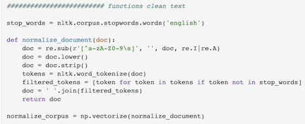

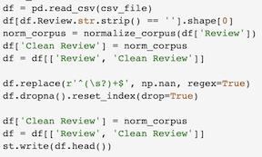

`OOV` -> Out of Vocab will replace any unkown words with this special token.

limiting vocabulary size to 10000 in the dataset. Only the top num_words will be considered.

```python
tokenizer = Tokenizer(num_words=10000,oov_token='<OOV>')
tokenizer.fit_on_texts(X_train)
```

`word_index` -> Used to see how tokens have been created and the indices assigned to words.

```python
word_index = tokenizer.word_index
print(word_index)
```

The Tokenizer is then fit on the training data only (X_train) to learn the vocabulary. Later, the texts_to_sequences method is applied separately to the training and testing sets to convert the text into sequences. Finally, the sequences are padded to a consistent length using pad_sequences.

`tokenizer.texts_to_sequences()` will be used to convert the text into sequences. Padding will also be implemented to the sequence to same length using `pad_sequences`.

This is a crucial step of preprocessing because as we know, machines can't understand text data as we do. In order to make the machine understand what we want is to convert the data into integers (sequence of numbers). Also, padding = 'post' will help us preserve the original order of the words.

```python
X_train_sequences = tokenizer.texts_to_sequences(X_train)
X_valid_sequences = tokenizer.texts_to_sequences(X_valid)
X_test_sequences = tokenizer.texts_to_sequences(X_test)

max_length = 250  # , 150, 500
X_train_padded = pad_sequences(X_train_sequences, maxlen = max_length, padding = 'post')
X_val_padded = pad_sequences(X_valid_sequences, maxlen = max_length, padding = 'post')
X_test_padded = pad_sequences(X_test_sequences, maxlen = max_length, padding = 'post')
```

# LSTM Model

This model was taken from tutorial Google Colab tutorial "IMDB Movie review.ipynb". Extra ideas were taken from Applied Machine Learning course, Introduction to NLP, and internet sources which helped me complete the model regarding regularization techniques, TensorBoard, model structure etc. Parameters like max_length, epochs, dropout numbers were randomly chosen after many experiments. Why regularization techniques using L2 and dropout? My model was suffering from cases of very low accuracy scores, high training losses and low validation losses. My model was mostly overfitting and sometimes underfitting. After playing with the max_length, epochs, and integers within the dropout I managed to get the highest accuracy score and best validation/training loss behavior.

Validation and Training behavior can be seeing using the TensorBoard dashboard below. Other options like histograms, graphs etc. can be selected within the dashboard. Very useful tool to see real time experimentation. I got the idea from Applied Machine Learning course.

Colab tutotial: https://colab.research.google.com/github/dipanjannC/Deep-Learning/blob/master/IMDB_Movie_review.ipynb#scrollTo=L0y6pKlrHfHS

- The tutorial is following Keras IMDB movie dataset and I am following the Kaggle IMDB Movie 50k Reviews.
- LSTM Layer is known as the Long Short Term Memory layer (type of RNN model). LSTM is a type of recurrent neural network but is better than traditional recurrent neural networks in terms of memory. Having a good hold over memorizing certain patterns LSTMs perform fairly better. This type of model is extremely useful in memorizing important information. The model will be able to find out the actual meaning in input string and will give the most accurate output class.

## Training and TensorBoard

```python
from tensorflow.keras.regularizers import l2
```

Extra Information:

- The `embedding layer` has weights that are learned. This layer is responsable for converting the sequences (input) into embedding vectors and learns the word embedding during training.
- `Sigmoid Activation Function` Will always returns a value between 0 and 1.

$$\text{Sigmoid}(x) = \sigma(x) = \frac{1}{1 + e^{-x}}$$

- `Binary Cross Entropy` Computes the cross-entropy loss between true labels and predicted labels.

$$\mathcal{L}_{\text{BCE}}(y, \hat{y}) = -\frac{1}{N}\sum_{i=1}^{N} y_i \log(\hat{y_i}) + (1 - y_i) \log(1 - \hat{y_i})$$

```python
vocab_size = len(tokenizer.word_index) + 1
embedding_dim = 32
input_length = max_length
batch = 32 # Keras batch size default "APML"
epochs = 15 # 10

with tf.device('/GPU:0'):  # using GPU for faster run
    model = Sequential()
    model.add(Embedding(vocab_size, embedding_dim, input_length = max_length))
    model.add(Dropout(0.5)) #5, 5, 5, 5, 5, 3
    model.add(LSTM(100, kernel_regularizer=l2(0.01)))
    model.add(Dropout(0.1)) #1, 15, 45, 5, 4, 4
    model.add(Dense(1, activation = 'sigmoid'))
    model.compile(loss='binary_crossentropy', # Loss also used within my CNN model from last semester
                  optimizer = 'adam', # Adam(learning_rate=0.0001)
                  metrics=['accuracy'])

    log_dir = "logs/fit/" + datetime.datetime.now().strftime("%Y%m%d-%H%M%S")
    tensorboard_callback = tf.keras.callbacks.TensorBoard(log_dir=log_dir, histogram_freq=1)

    with tf.device('/GPU:0'):
      history = model.fit(X_train_padded, y_train,
                          validation_data=(X_val_padded, y_valid),
                          epochs=epochs,
                          batch_size=batch,
                          callbacks=[tensorboard_callback])
```

```python
model.summary()
```

```
Model: "sequential_1"
_________________________________________________________________
 Layer (type)                Output Shape              Param #
=================================================================
 embedding_1 (Embedding)     (None, 250, 32)           3241664

 dropout_2 (Dropout)         (None, 250, 32)           0

 lstm_1 (LSTM)               (None, 100)               53200

 dropout_3 (Dropout)         (None, 100)               0

 dense_1 (Dense)             (None, 1)                 101

=================================================================
Total params: 3,294,965
Trainable params: 3,294,965
Non-trainable params: 0
_________________________________________________________________
```

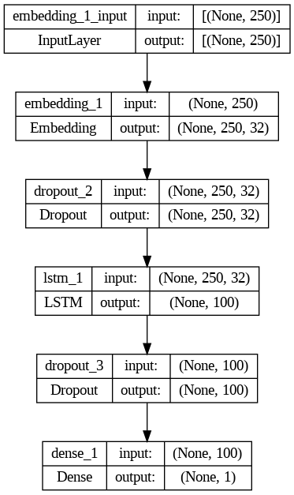

```python
plot_model(model, to_file='model_plot.png', show_shapes=True, show_layer_names=True)
```

```python
%tensorboard --logdir logs/fit
```

[figure not shown]

```python
min_loss = min(history.history['loss']) # APML Homework
min_val_loss = min(history.history['val_loss'])
max_tr_acc = max(history.history['accuracy'])
max_val_acc = max(history.history['val_accuracy'])

print(f'The lowest training loss after 15 epochs is: {min_loss}')
print(f'The lowest val loss after 15 epochs is: {min_val_loss}')
print('\n')
print(f'The hightest training accuracy after 15 epochs is: {max_tr_acc}')
print(f'The hightest validation accuracy after 15 epochs is: {max_val_acc}')
```

```
The lowest training loss after 15 epochs is: 0.30322331190109253
The lowest val loss after 15 epochs is: 0.325209379196167


The hightest training accuracy after 15 epochs is: 0.8812187314033508
The hightest validation accuracy after 15 epochs is: 0.8736249804496765
```

As mentioned before, our highest train accuracy is of 88% after experimenting with different cases, integers, and techniques. Since this is my first time working with LSTM Model, I wanted it to try and keep it simple regarding accuracy score and epochs. Many tutorials found on internet has pretty good accuracy scores, however many models were extremely overfitting.

The following image, shows one of my first experiments where my model was sufffering from underfitting:

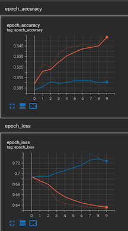

## Evaluation and Testing

```python
# Evaluation
loss, test_accuracy = model.evaluate(X_test_padded, y_test)

print(f'The loss for LSTM Model is: {loss}')
print(f'The test Accuracy for LSTM Model is: {test_accuracy}')
```

```
The loss for LSTM Model is: 0.33174842596054077
The test Accuracy for LSTM Model is: 0.8675000071525574
```

Let's print 5 random prediction to tets our model.

```python
X_test_arr = np.array(X_test)

# Testing
predictions = model.predict(X_test_padded)

final_pred = decoded_predictions = np.where(predictions > 0.5, 'positive', 'negative')

# Random predictions to test the model
print('Random Predictions:')
random = np.random.choice(len(X_test), size=5, replace=False)
for i in random:
    print(f'Review: {X_test_arr[i]}')
    print(f'Prediction: {final_pred[i]}')
    print()
```

```
Random Predictions:
Review: Like the previous commentator on this film, I too found myself in tears at times during this movie. Sometimes one wonders how a film of such awe-inspiring awfulness comes into existence. From the first moment when our protagonist wakes up in his New York apartment from a dream of subway trai…
Prediction: ['positive']

Review: I am a huge fan of Northern Exposure. Men In Trees is a complete knock-off of Northern Exposure. There's the city-folk from New York stuck in a remote backwoods town (Marin Frist / Joel Fleishman). She immediately doesn't hit it off with a local (Jack Slattery / Maggie O'Connell). The town o…
Prediction: ['negative']

Review: Truly awful. Obviously an attempt to cash in on the Star Wars craze, but there's no excuse for this insipid piece of garbage. The storyline gets lost before the middle, the characters are forgettable and the kid is such a non-talent that all he does is pose for the camera. An alien planet th…
Prediction: ['negative']

Review: What can I say? After having read Herbert's books and loving Lynch's movie version, I was extremely disappointed. I felt I was watching a reject version of Buck Rogers. The sets looked like left overs from a Star Wars TV special! I felt the acting was a bit amateurish by most. The costumes w…
Prediction: ['negative']

Review: when i saw commercials for this i was thinking "NO WHAT HAS NICK AT NITE DONE!" because it was taking up "fresh prince" slots. well, i still love the fresh prince. but george lopez is a surprisingly good show. i love how not-stereotypical benny is. carmen is a pretty good character, its real…
Prediction: ['positive']
```

# References

- Kaggle Data: https://www.kaggle.com/datasets/lakshmi25npathi/imdb-dataset-of-50k-movie-reviews?resource=download
- GPUs: https://www.tensorflow.org/guide/gpu
- Colab: https://colab.research.google.com/github/dipanjannC/Deep-Learning/blob/master/IMDB_Movie_review.ipynb#scrollTo=L0y6pKlrHfHS
- Label Encoding: https://www.analyticsvidhya.com/blog/2020/03/one-hot-encoding-vs-label-encoding-using-scikit-learn/
- Tokenizer: https://www.tensorflow.org/api_docs/python/tf/keras/preprocessing/text/Tokenizer
- Tokenizer, Sequences, Padding: https://dev.to/balapriya/tokenization-and-sequencing-in-tensorflow-3p0n
- Tokenizer: https://www.kdnuggets.com/2020/03/tensorflow-keras-tokenization-text-data-prep.html
- num_words: https://stackoverflow.com/questions/53525994/how-to-find-num-words-or-vocabulary-size-of-keras-tokenizer-when-one-is-not-as
- OOV: https://www.kaggle.com/code/hamishdickson/using-keras-oov-tokens
- LSTM Layer: https://www.analyticsvidhya.com/blog/2021/06/lstm-for-text-classification/
- Embedding: https://www.mathworks.com/help/textanalytics/ref/nnet.cnn.layer.wordembeddinglayer.html#
- Embedding: https://machinelearningmastery.com/use-word-embedding-layers-deep-learning-keras/
- Binary Cross Entropy Loss: https://www.tensorflow.org/api_docs/python/tf/keras/losses/BinaryCrossentropy
- Dropout: https://medium.datadriveninvestor.com/deep-learning-lstm-for-sentiment-analysis-in-tensorflow-with-keras-api-92e62cde7626
- TensorBoard with Keras Model.fit(): https://www.tensorflow.org/tensorboard/get_started
- L2 Penalty: https://www.tensorflow.org/api_docs/python/tf/keras/regularizers/L2
- L2 Penalty: https://keras.io/api/layers/regularizers/
- Binary Cross Entropy: https://www.tensorflow.org/api_docs/python/tf/keras/losses/BinaryCrossentropy
- Test score and test accuracy: https://stackoverflow.com/questions/43589842/test-score-vs-test-accuracy-when-evaluating-model-using-keras
- Other reference model: https://www.kaggle.com/code/rivals16/imdb-movie-review-nlp-lstm-with-dnn